# Machine Learning Final Project

C. McBride

March 1, 2018

### The Dataset

The dataset consisted of 19,622 observations on 160 variables, most of which were float values correponding to the measurements take from the accelerometers. The small number of non-numeric variables were related to data collection and included factors such as subject name and time stamps. These factor type variables were dropped from the data since they did not serve as meaningful predictors of the classification variable. The classification variable (`classe`) was of factor type with five levels (capital letters A through E).

```r
# Load training data
d <- read.csv("pml-training.csv")

# Change variables to class numeric
d[, 8:159] <- apply(d[, 8:159], 2, function(x) as.numeric(x))

# summarize data
dim(d)
```

```
## [1] 19622   160
```

```r
# Remove variables with high proportion of NA's
missing <- c()
for(i in seq_along(names(d))){if(sum(is.na(d[, i])) > 0)missing <- c(missing, i)}
d <- d[, -missing]

# Make vector class adjustments
d$classe <- as.factor(d$classe)

# Pre-select relevant features
d <- d[8:60]
```

Next, zero- and near-zero-variance variables were removed from the data because there variable can cause machine learning models to crash or become unstable. This step also identifies and eliminates variables with a few observations that fall outside of a narrow, near-variance. Such variables run the risk of being split unrepresentatively when dividing the data into train and validation sets.

```r
# Test near-zero variance and remove problematic variables
nzv <- nearZeroVar(d, saveMetrics = T)
d <- d[, !nzv$nzv]
```

After the data was cleaned and some of the preprocessing steps were completed (others were included as calls to the model functions), the data was divided into training and validation subsets. The seed for the random function was set to facilitate reproducibility.

```r
# Partition data into training and validation
set.seed(1432)
trainSplit <- createDataPartition(y=d$classe, p = 0.7, list = F)
trainPML <- d[trainSplit, ]
validPML <- d[-trainSplit, ]
```

```r
# Set up parallel processing
cluster <- makeCluster(detectCores() - 1)
registerDoParallel(cluster)
```

### Cross-Validation

```r
# Configure trainControl object
fitControl <- trainControl(method = "repeatedcv",
                           repeats = 5,
                           number = 10,
                           allowParallel = TRUE)
```

The distribution of levels in the outcome variable show some variability but overall appear robust against the algorithms predicting one variable significantly better than others.

```r
# check balance of among levels withing response variable
table(trainPML$classe)/nrow(trainPML)
```

```
##
##         A         B         C         D         E
## 0.2843416 0.1934920 0.1744195 0.1639368 0.1838101
```

```r
table(validPML$classe)/nrow(validPML)
```

```
##
##         A         B         C         D         E
## 0.2844520 0.1935429 0.1743415 0.1638063 0.1838573
```

### Algorithms

**Random Forest**

The first model used was a random forest algorithm. Although it took considerably longer to train, that some of the other options, it was by far the best performing algorithm judging by accuracy. The confusion matrix for this model over the validation set, shows low relative Type I and Type II errors, along for a very high accuracy considering the small amount of tuning that went into the implementation.

```r
# Random Forest Training model
dTree <- train(classe ~ .,
               method = 'rf',
               preProcess = c("pca", "scale"),
               data = trainPML,
               trControl = fitControl)

# save model
saveRDS(dTree, "dtree_model.rds")
```

```r
# load model
dTree <- readRDS("dtree_model.rds")

# predictions on validation data
prd <- predict(dTree, newdata = validPML)

# confusion matrix
confusionMatrix(prd, validPML$classe)
```

```
## Confusion Matrix and Statistics
##
##           Reference
## Prediction    A    B    C    D    E
##          A 1660   18    1    2    0
##          B    5 1110   13    1    8
##          C    5   11  999   42    3
##          D    2    0   10  918    5
##          E    2    0    3    1 1066
##
## Overall Statistics
##
##                Accuracy : 0.9776
##                  95% CI : (0.9735, 0.9812)
##     No Information Rate : 0.2845
##     P-Value [Acc > NIR] : < 2.2e-16
##
##                   Kappa : 0.9716
##  Mcnemar's Test P-Value : 3.98e-06
##
## Statistics by Class:
##
##                      Class: A Class: B Class: C Class: D Class: E
## Sensitivity            0.9916   0.9745   0.9737   0.9523   0.9852
## Specificity            0.9950   0.9943   0.9874   0.9965   0.9988
## Pos Pred Value         0.9875   0.9763   0.9425   0.9818   0.9944
## Neg Pred Value         0.9967   0.9939   0.9944   0.9907   0.9967
## Prevalence             0.2845   0.1935   0.1743   0.1638   0.1839
## Detection Rate         0.2821   0.1886   0.1698   0.1560   0.1811
## Detection Prevalence   0.2856   0.1932   0.1801   0.1589   0.1822
## Balanced Accuracy      0.9933   0.9844   0.9806   0.9744   0.9920
```

Both the accuracy and kappa values are very strong indicating that the accuracy is not at all random.

A plot of the error gradients, shows the model had explained most of the variation within the data even with a relatively low number of component trees.

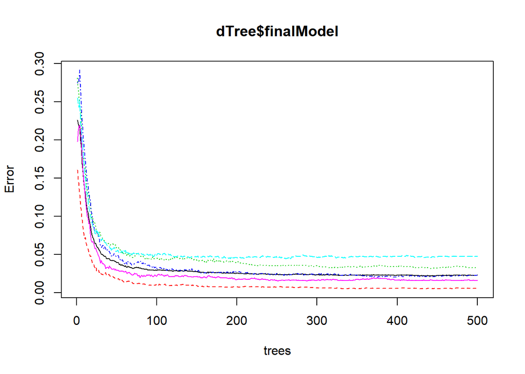

```r
# plot of erro gradients
plot(dTree$finalModel)
```

**Gradient Boosted Regression Model**

The next model that was investigated was the gradient boosted regression model. While the results of the model were still statistically significant, the overall all predictive power of this model fell far short of the random forest analogue.

```r
# Gradient Boost Training model
gbmGrid <-  expand.grid(interaction.depth = c(1, 5, 9),
                        n.trees = (1:30)*50,
                        shrinkage = 0.1,
                        n.minobsinnode = 20)

gBoost <- train(classe ~ .,
                method ="gbm",
                preProcess = c("pca", "scale"),
                data = trainPML,
                trControl = fitControl,
                verbose = FALSE,
                tuneGrid = gbmGrid)

# save model
saveRDS(gBoost, "gboost_model.rds")
```

```r
# load model
gBoost <- readRDS("gboost_model.rds")

# predictions on validation data
prd <- predict(gBoost, newdata = validPML)

# confusion matrix
confusionMatrix(prd, validPML$classe)
```

```
## Confusion Matrix and Statistics
##
##           Reference
## Prediction    A    B    C    D    E
##          A 1488  115   40   51   32
##          B   37  852   57   25   92
##          C   64  113  882  118   71
##          D   73   25   28  744   38
##          E   12   34   19   26  849
##
## Overall Statistics
##
##                Accuracy : 0.8182
##                  95% CI : (0.8081, 0.828)
##     No Information Rate : 0.2845
##     P-Value [Acc > NIR] : < 2.2e-16
##
##                   Kappa : 0.7699
##  Mcnemar's Test P-Value : < 2.2e-16
##
## Statistics by Class:
##
##                      Class: A Class: B Class: C Class: D Class: E
## Sensitivity            0.8889   0.7480   0.8596   0.7718   0.7847
## Specificity            0.9435   0.9555   0.9247   0.9667   0.9811
## Pos Pred Value         0.8621   0.8015   0.7067   0.8194   0.9032
## Neg Pred Value         0.9553   0.9405   0.9689   0.9558   0.9529
## Prevalence             0.2845   0.1935   0.1743   0.1638   0.1839
## Detection Rate         0.2528   0.1448   0.1499   0.1264   0.1443
## Detection Prevalence   0.2933   0.1806   0.2121   0.1543   0.1597
## Balanced Accuracy      0.9162   0.8518   0.8922   0.8692   0.8829
```

**Naive Bayes**

The next model that was attempted as a classifier for this dataset relied on a naive Bayes algorithm.

```r
# train naive Bayes model
naiveBayes <- train(classe ~ .,
                   method ="naive_bayes",
                   preProcess = c("pca", "scale"),
                   data = trainPML,
                   trControl = fitControl)

# save model
saveRDS(naiveBayes, "naive_bayes_model.rds")
```

```r
# load model
naiveBayes <- readRDS("naive_bayes_model.rds")

# predictions on validation data
prd <- predict(naiveBayes, newdata = validPML)

# confusion matrix
confusionMatrix(prd, validPML$classe)
```

```
## Confusion Matrix and Statistics
##
##           Reference
## Prediction    A    B    C    D    E
##          A 1153  176  191  104   46
##          B  100  675   97   39  164
##          C  209  115  641  148   94
##          D  196   89   54  607   58
##          E   16   84   43   66  720
##
## Overall Statistics
##
##                Accuracy : 0.645
##                  95% CI : (0.6326, 0.6573)
##     No Information Rate : 0.2845
##     P-Value [Acc > NIR] : < 2.2e-16
##
##                   Kappa : 0.5514
##  Mcnemar's Test P-Value : < 2.2e-16
##
## Statistics by Class:
##
##                      Class: A Class: B Class: C Class: D Class: E
## Sensitivity            0.6888   0.5926   0.6248   0.6297   0.6654
## Specificity            0.8772   0.9157   0.8835   0.9193   0.9565
## Pos Pred Value         0.6904   0.6279   0.5311   0.6046   0.7750
## Neg Pred Value         0.8764   0.9035   0.9177   0.9269   0.9270
## Prevalence             0.2845   0.1935   0.1743   0.1638   0.1839
## Detection Rate         0.1959   0.1147   0.1089   0.1031   0.1223
## Detection Prevalence   0.2838   0.1827   0.2051   0.1706   0.1579
## Balanced Accuracy      0.7830   0.7542   0.7541   0.7745   0.8110
```

**Regularized Discriminant Analysis**

```r
# regularized disriminant analysis
rda_model <- train(classe ~ .,
                   method = "rda",
                   preProcess = c("pca"),
                   data = trainPML,
                   trControl = fitControl)

# save model
saveRDS(rda_model, "rda_model.rds")
```

```r
# load model
rda_model <- readRDS("rda_model.rds")

# predictions on validation data
prd <- predict(rda_model, newdata = validPML)

# confusion matrix
confusionMatrix(prd, validPML$classe)
```

```
## Confusion Matrix and Statistics
##
##           Reference
## Prediction    A    B    C    D    E
##          A 1101   38    4   15    1
##          B  210  909   96   75  127
##          C  292  171  890  233   55
##          D   57    7   33  615  122
##          E   14   14    3   26  777
##
## Overall Statistics
##
##                Accuracy : 0.7293
##                  95% CI : (0.7178, 0.7406)
##     No Information Rate : 0.2845
##     P-Value [Acc > NIR] : < 2.2e-16
##
##                   Kappa : 0.6614
##  Mcnemar's Test P-Value : < 2.2e-16
##
## Statistics by Class:
##
##                      Class: A Class: B Class: C Class: D Class: E
## Sensitivity            0.6577   0.7981   0.8674   0.6380   0.7181
## Specificity            0.9862   0.8930   0.8454   0.9555   0.9881
## Pos Pred Value         0.9500   0.6415   0.5424   0.7374   0.9317
## Neg Pred Value         0.8788   0.9485   0.9680   0.9309   0.9396
## Prevalence             0.2845   0.1935   0.1743   0.1638   0.1839
## Detection Rate         0.1871   0.1545   0.1512   0.1045   0.1320
## Detection Prevalence   0.1969   0.2408   0.2788   0.1417   0.1417
## Balanced Accuracy      0.8220   0.8455   0.8564   0.7967   0.8531
```

```r
# prepare data for ovelapping density plot
density_data <- cbind("RDA",
                      rda_model$resample$Accuracy,
                      rda_model$resample$Kappa)

density_data <- rbind(density_data,
                      cbind("GBM",
                            gBoost$resample$Accuracy,
                            gBoost$resample$Kappa))

density_data <- rbind(density_data,
                      cbind("Naive Bayes",
                            naiveBayes$resample$Accuracy,
                            naiveBayes$resample$Kappa))

density_data <- rbind(density_data,
                      cbind("Random Forest",
                            dTree$resample$Accuracy,
                            dTree$resample$Kappa))

density_data <- as.data.frame(density_data)

density_data$V2 <- as.double(as.character(density_data$V2))
density_data$V3 <- as.double(as.character(density_data$V3))

names(density_data) <- c("Model", "Accuracy", "Kappa")
```

### Performance & Conclusions

The random forest algorithm was by far the best at accurately predicting movement type. Both it’s accuracy measure and kappa value were very robust. The other models lagged behind the random forest implementation in both measures.

Density plots of the cross-validation resampling distributions for each model’s kappa and accuracy values underscores the differences in performance and the superiority of the random forest model.

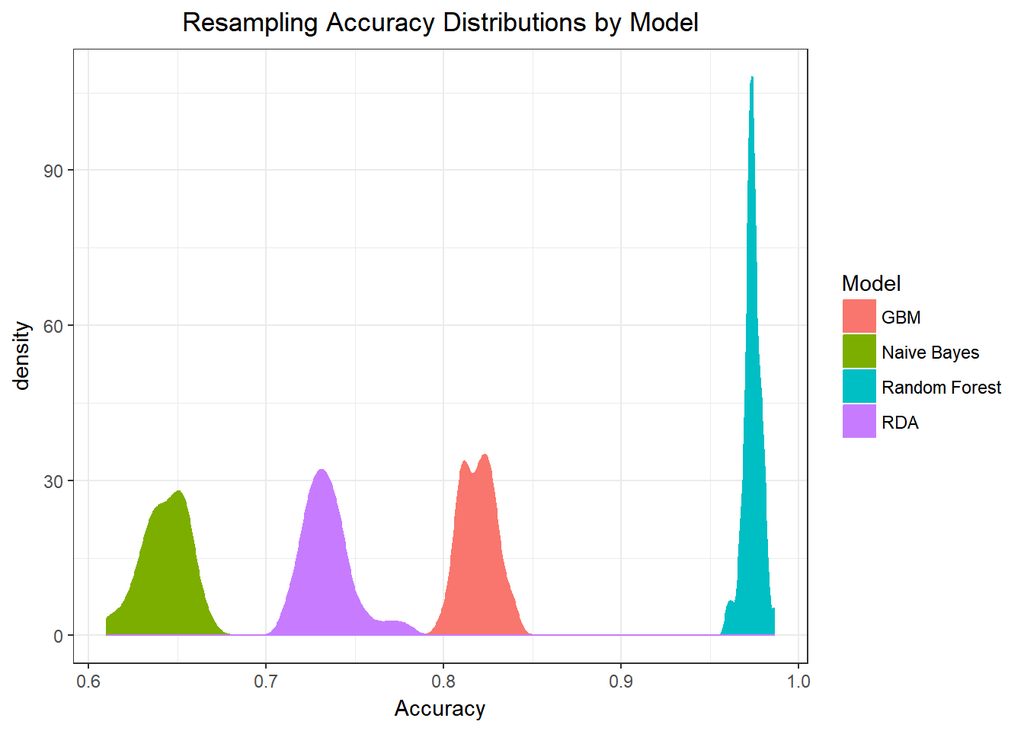

```r
# plot accuracy density
ggplot(density_data) +
        geom_density(aes(x=Accuracy,
                         group=Model,
                         color=Model,
                         fill= Model)) +
        labs(title="Resampling Accuracy Distributions by Model") +
        theme_bw() +
        theme(plot.title = element_text(hjust = 0.5))
```

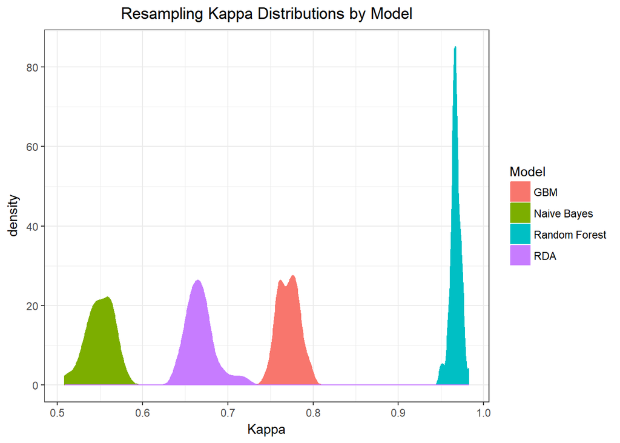

```r
# plot accuracy density
ggplot(density_data) +
        geom_density(aes(x=Kappa,
                         group=Model,
                         color=Model,
                         fill= Model)) +
        labs(title="Resampling Kappa Distributions by Model") +
        theme_bw() +
        theme(plot.title = element_text(hjust = 0.5))
```

### Testing Code

```r
# load test data
t <- read.csv("pml-testing.csv")
```

```r
# format and clean test data
# Change variables to class numeric
t[, 8:159] <- apply(t[, 8:159], 2, function(x) as.numeric(x))

# match features in test df to train df
t <- t[, names(trainPML)[1:52]]
```

```r
# predictions on test set by model
rda_predictions <- predict(rda_model, newdata = t)
nb_predictions <- predict(naiveBayes, newdata = t)
rf_predictions <- predict(dTree, newdata = t)
gb_predictions <- predict(gBoost, newdata = t)
```